# Data analysis

Miao Zhang

2/6/2019

# 1. Overall kinematic analysis

## 1.1. Gesture Duration

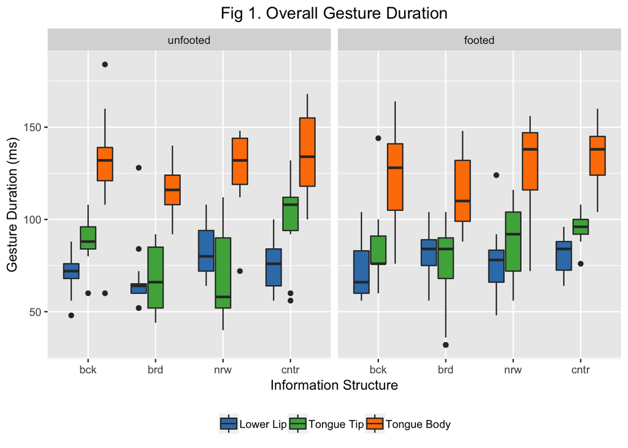

The main factor *Place of Articulation* also has an effect on *gesture duration* (F(2, 286) = 204.50 (p < .001), post-hoc: /k/ > /t/ > /p/).

Table 1.1. Interaction between place of Articulation and information structure in gesture duration

| Place | bck | brd | nrw | cntr |
| --- | --- | --- | --- | --- |
| lower_lip | 71.36296 | 75.052 | 79.48929 | 77.80370 |
| tongue_tip | 86.66667 | 72.000 | 78.88000 | 98.16667 |
| tongue_body | 127.00000 | 116.000 | 128.61538 | 134.15385 |

Effects of *Footedness* on *gesture duration* failed to reach the level of significance.

## 1.2. Maximum Displacement

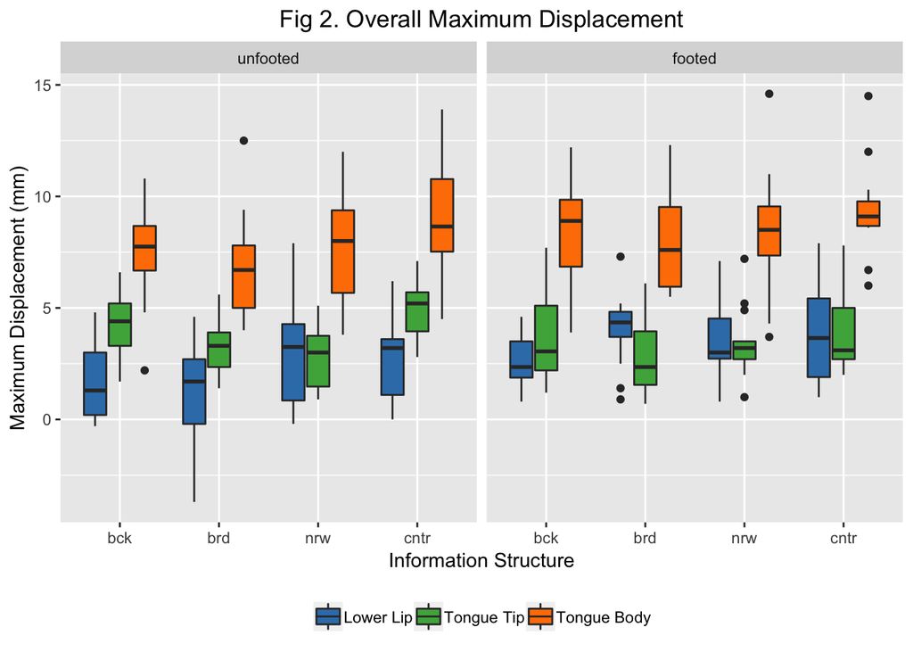

Fig 2. shows the distribution of maximum displacement of the opening gesture in different conditions. I observed larger movements across different *Information structures*: F(3, 286) = 6.82 (p < .001). *Across-accentuation*, the opening gestures are averagely 1.14mm larger in *contrastive focus* than in *background*. *Within-accentuation*, the displacement of gestures increased from *broad focus* to *contrastive focus* for an average of 1.37mm, from *narrow focus* to *contrastive focus* for an average of 0.85mm.

*Place of articulation* again has an effect on displacement (F(2, 286) = 208.58 (p < .001), post-hoc: /k/ > /t/ > /p/).

Comparing the two *footedness* condition, the movement under footed conditions overall is 0.48mm larger than unfooted conditions (F(1, 286) = 4.36 (p < .05)).

The interaction of *place* and *footedness* reached the level of significance (F(2, 286) = 5.075 (p < .01)).

Table 1.2. Interaction between footedness and place of articulation in displacement

| Footedness | lower_lip | tongue_tip | tongue_body |
| --- | --- | --- | --- |
| unfooted | 2.145283 | 3.812500 | 7.841177 |
| footed | 3.527778 | 3.442593 | 8.464000 |

As can be seen from the table, whereas for *lower lip* and *tongue body*, the articulators moved larger from unfooted condition to footed condition, *tongue tip* moved smaller.

## 1.3. Peak Velocity

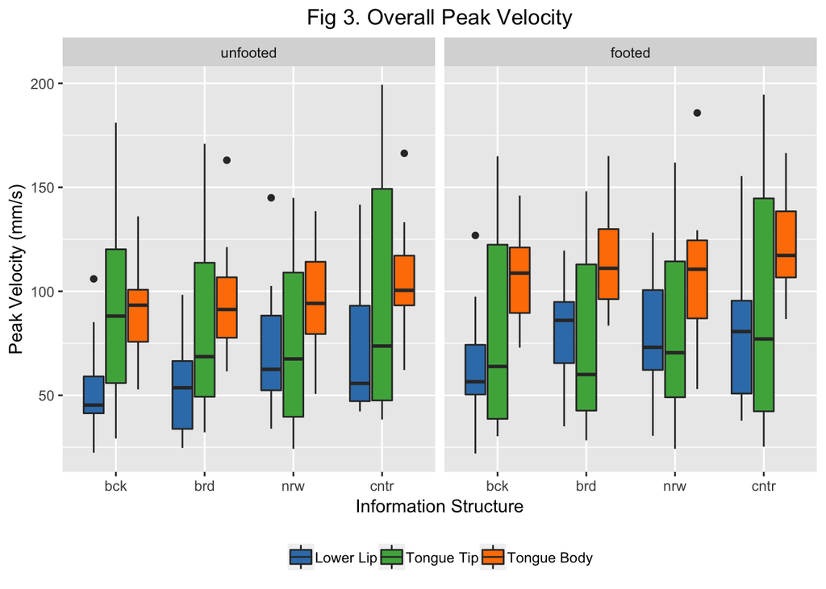

No significant differeces due to *information structure* was confirmed but it was statistically close (F(3, 286) = 2.26, p < .1). On the other hand, *footedness* (F(1, 286) = 4.09 (p < .05); post-hoc: 8.23mm/s faster when footed than unfooted) and *place of articulation* (F(2, 286) = 25.1498 (p < .05); post-hoc: /k/ > /t/ > /p/) both have a main effect on how fast the articulators move. Interactions between the three variables were not significant for peak velocity.

## 1.4. Time-to-Peak Velocity

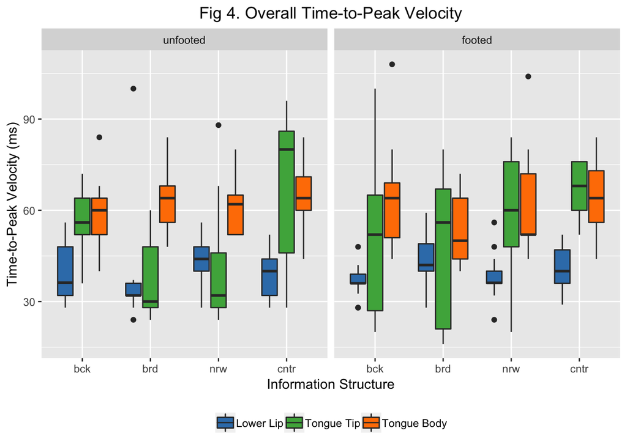

An effect of *Information structureand* on *time-to-peak velocity* was observed (F(3, 286) = 6.12 (p < .05)). *Across-accentuatoin*, there is a less stiff movement comparing *contrastive focus* to *background* (6.34ms later). *Within-accentuation* time-to-peak velocity is 9.83ms later in *contrastive focus* than in *broad focus*. Though not significant, the difference between contrastive focus and narrow focus of 5.78ms is just above significant level (p-adjusted = 0.06).

The *place of articulation* again is significant (F(2, 286) = 59.41 ( p < .05); post-hoc: /k/ > /t/ > /p/).

Table 1.3. Interaction between information structure and place of articulation

| Info_str | lower_lip | tongue_tip | tongue_body |
| --- | --- | --- | --- |
| bck | 37.88148 | 53.03704 | 61.83333 |
| brd | 40.49200 | 42.76923 | 57.92000 |
| nrw | 41.20357 | 51.20000 | 61.53846 |
| cntr | 40.47037 | 66.66667 | 64.76923 |

# 2. By-speaker analysis

There is a huge inter-speaker variation observed from the data. A series of two-way ANOVAs taking *information structure* and *footedness* as the independent variables was run by each speaker for each kinematic measurement. The table below summarises the result of the analysis by speakers. Since the interaction between information structure and footedness was not confirmed statistically, in the by-speaker analysis below, the result involving footedness will not be reported below.

## Table 1. Across-accentuation by-speaker comparison

| Speaker | C vs 0 |  |  |  | N vs 0 |  |  |  | B vs 0 |  |  |  |
| --- | --- | --- | --- | --- | --- | --- | --- | --- | --- | --- | --- | --- |
| ——- | Longer | Larger | Faster | Less stiff | Longer | Larger | Faster | Less stiff | Longer | Larger | Faster | Less stiff |
| F1 | /t/ | /t/ | - | /t/ |  | - | - | - | - | - | - | - |
| F2 | - | /p/ | /p/ |  | - | /t/ | - | - | - | - | - | - |

## Table 2. Within-accentuation by-speaker comparison

| Speaker | C vs B |  |  |  | C vs N |  |  |  | N vs B |  |  |  |
| --- | --- | --- | --- | --- | --- | --- | --- | --- | --- | --- | --- | --- |
| ——- | Longer | Larger | Faster | Less stiff | Longer | Larger | Faster | Less stiff | Longer | Larger | Faster | Less stiff |
| F1 | /t/ | /t/ | - | /t/ | /t/ | /t/ | - | /t/ | - | - | - | /t/ |
| F2 | - | /t/ | /t/ | - | - | - | - | - | - | - | - | - |

# 2.1. Effects of information structures

From the two tables above, it’s quite clear that significant modifications in kinematic measurements are present in the comparisons between contrastive focus condition and other focus contexts. F1 displayed siginificant modified movement comparing contrastive focus to all other focus conditions and F2 also showed modification in comparing contrastive focus to background and broad focus contexts. There was some sporadic modification seen in both F1 and F2 when comparing focus conditions that don’t include contrastive focus though, only one measurement of one of the articulators were affected (for F2, N vs 0, for F1, N vs B).

This observation seems to conform to what was suggested in Mucke & Grice (2014) that it is prominence rather than accentuation that leads to modification in supralaryngeal articulation. The effect of information structures is still very salient despite that in my data, the target gestures are in unstressed syllables where the vowels undergo reduction and become schwas. This might further suggest that the effect of prominence-related articulatory modification is not to be considered as bound with accentuation since unstressed syllables do not get the pitch accents docked onto them, not even pre-nuclear pitch accents.

# 2.2. Effects of places of articulation

It is evident from the data above that not all articulators are affected equally by the information structures for the speakers. Tongue body failed to display any disernible modifications in any kind of conditions. Lower lip is influenced only for F2 in the comparison between contrastive focus and background. In contrast, tongue tip seemed to have been influenced largely by information structure. Both speaker modified the movement of tongue tip to some extent in certain focus conditions. The modification of tongue tip is seen in C vs 0, C vs B, and C vs N comparisons for F1, and C vs B comparison for F2.

# 2.3. Articulatory strategies

F1 and F2 differ in terms of the strategy they make use of to modifying articulation in response to the change (increase) in prominence. In cases where there were significant articulatory modifications, F1 consistantly made longer, larger and less stiff but not faster movements, whereas F2 consistantly made larger and faster movements but neither longer nor faster. This indicates that while F2 tend to use rescaling (changing maximum displacement and peak velocity) as the strategy to modify articulation, F1 tend to use a combined strategy of stiffness modification (changing time-to-peak velocity and duration) and truncation (changing gesture duration and maximum displacement). Important is that although interspeaker variability was huge, within each speaker, the strategy being used is highly consistant, even though speaker may apply the same strategy to different articulators as seen in the case of F2.

# 3. Summary

1. Supralaryngeal articulation is influenced by information structure, place of articulation and footedness even when the target gesture is in unstressed syllables which are subjects to reduction in English.
2. Prominence rather than accentuation leads to articulatory modification.
3. While footedness did have influence on articulation, it does not interfere with the effect of information structure.
4. In unstressed syllables, not all gestures are equally affected by information structure. Tongue body movement were largely unaffected probably due to that tongue body is a much less flexible articulator compared to tongue tip and lower lip.
5. There is a clear interspeaker variability in terms of which kind of articulatory strategy is being used to achieve the modification of supralaryngeal articulation, however, intraspeaker consistency is also very evident.

# Appendix 1. The kinematic measurements of each speaker

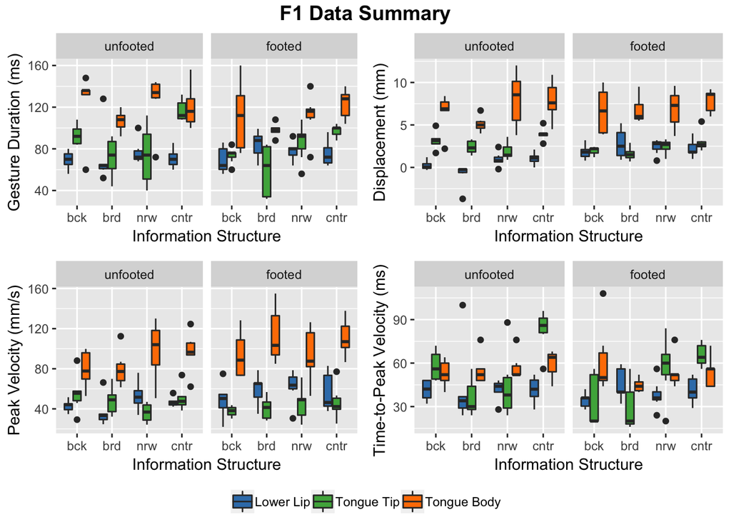

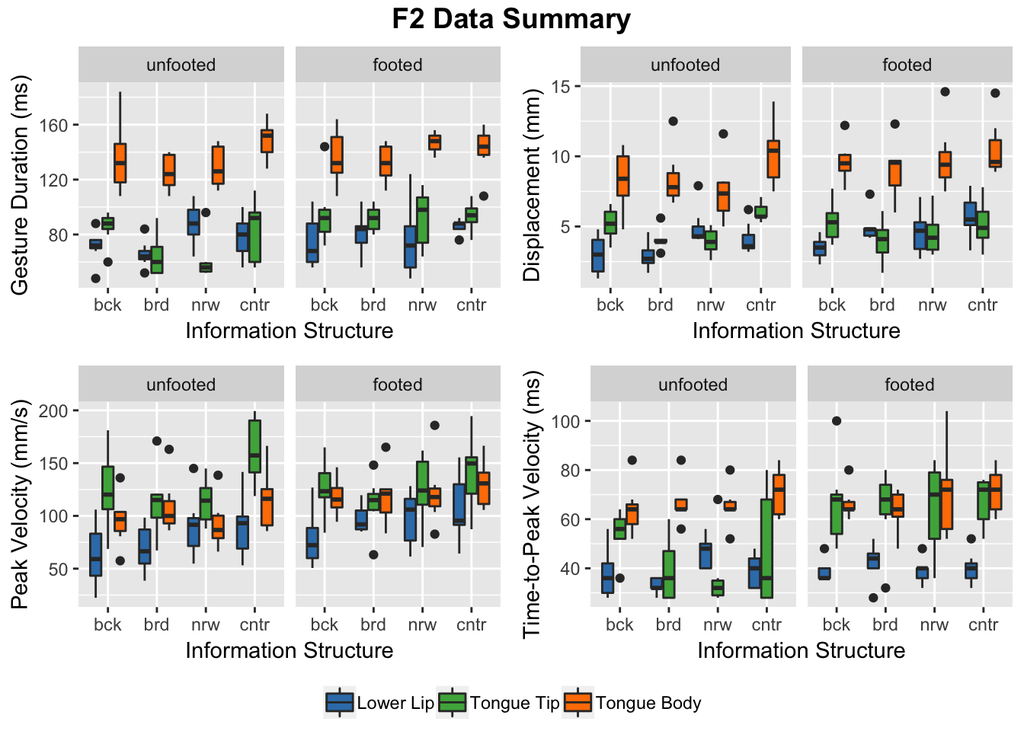